# Chapter 1: Simple Linear Regression

Part 1

Author

MATH 360

Consider the kinds of questions that can be answered when using a quantitative variable to predict another quantitative variable.

# 1 Research Questions

- Can cricket chirps be used to predict the temperature?
- Does electrical stimulation of the brain help with problem solving?
- To what extent does economic growth depend on the inflation rate?
- Can we predict Rotten Tomatoes scores using movie budgets?
- How strong is the dependence of college GPA on high school GPA?

# 2 Single Quantitative Predictor Model

- Notation:
  - $Y$ = response variable
  - $X$ = explanatory variable
- Assume $X$ and $Y$ are both quantitative (for now)
  $$\begin{align}
  \mbox{Data} &= \mbox{Model} + \mbox{Error}\\
  Y &= f(X) + \epsilon \\
  Y &= \mu_Y + \epsilon \\
  \end{align}$$

where $Y$ is assumed to be a linear function of $X$:

$$\mu_Y = \beta_0+\beta_1 X$$

## 2.1 Example: Predicting Final Score from Midterm Score

```r
MidtermFinal <- read.csv("http://people.kzoo.edu/enordmoe/math360/MidtermFinal.csv")
dim(MidtermFinal)
```

```
[1] 31  3
```

- First 6 cases

```r
head(MidtermFinal)
```

```
   Student Midterm Final
1  Katelin      35    53
2  Phoenix      38    68
3    Maria      50    93
4     Adam      39    80
5 Michelle      37    82
6  Allyssa      46    87
```

## 2.2 Graphing the Data

- Scatterplot with a smoother helps determine whether a linear model is appropriate.

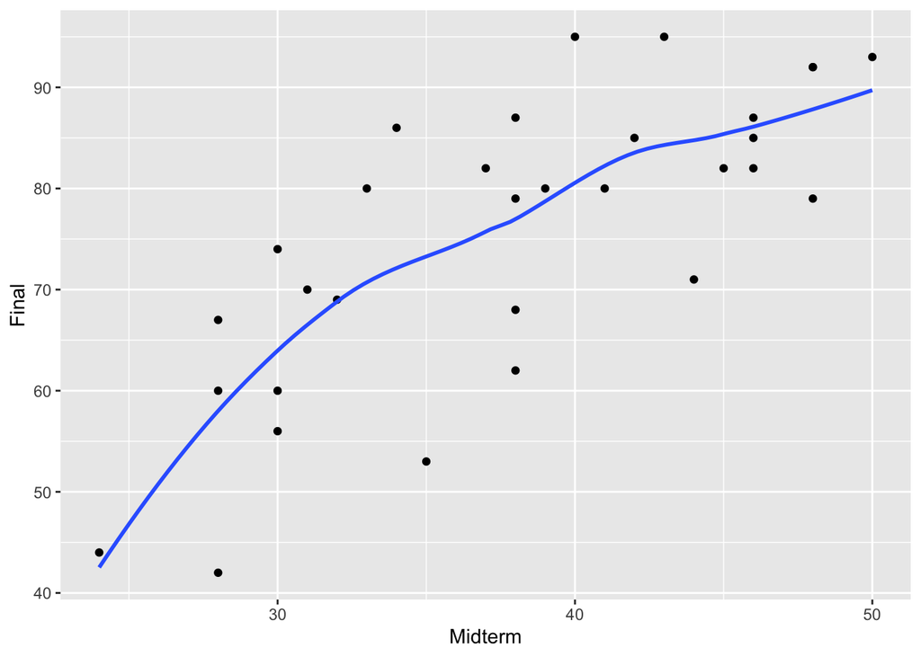

```r
gf_point(Final ~ Midterm, data = MidtermFinal) |>
  gf_smooth()
```

# 3 Fitting a Simple Least Squares Regression Model

- The fitted (or estimated) model is represented by
  $$\widehat Y = \hat\beta_0 + \hat\beta_1 X$$
  where
  - $\hat\beta_0$ is the intercept of the fitted line and
  - $\hat\beta_1$ is the slope of the fitted line

**Question:** How is the best line determined?

**Answer:** Minimize the sum of squared prediction errors

$$\mbox{SSE}=\sum(Y-\widehat Y)^2$$

That is, we minimized the errors in the **vertical** direction.

The fitted line is called the **least squares regression line** or just the **linear regression line**.

## 3.1 Least Squares Estimation

- Choose line that minimizes **sum of squares** of vertical distances
  - Residual = $Y-\hat Y$

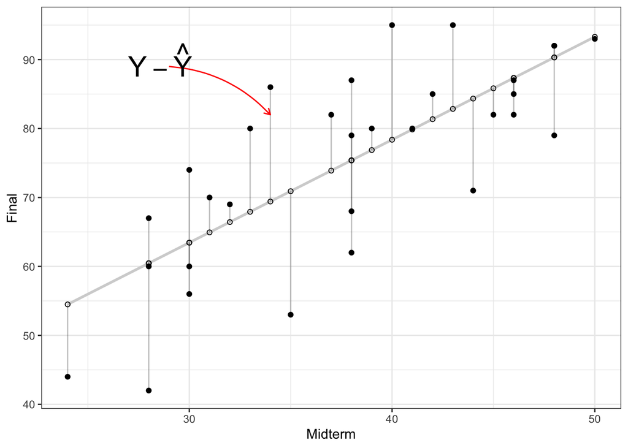

## 3.2 Example: Using R to Find and Plot the Regression Line

First, fit and save the regression model

```r
model1 <- lm(Final ~ Midterm, data = MidtermFinal)
#Obtain regression output including slope and intercept
model1
```

```
Call:
lm(formula = Final ~ Midterm, data = MidtermFinal)

Coefficients:
(Intercept)      Midterm
     18.672        1.492
```

Use R to plot the regression line on the scatterplot.

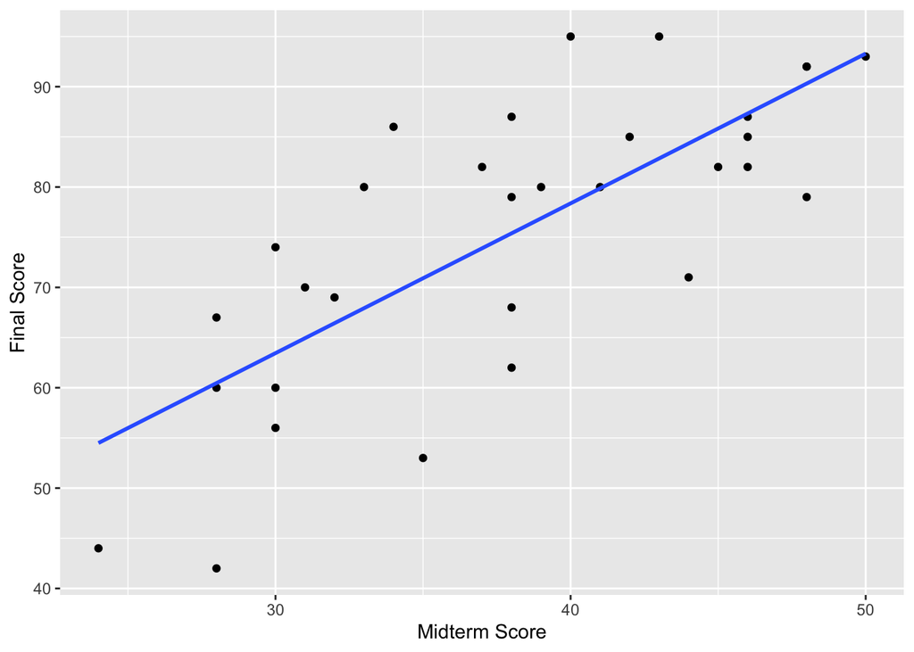

```r
# Graph regression line on scatterplot
gf_point(Final ~ Midterm, data = MidtermFinal,
         xlab = "Midterm Score", ylab = "Final Score") |>
  gf_smooth(method = "lm")
```

## 3.3 The Fitted Regression Equation

$$\begin{align*}
\hat Y &= 18.67 + 1.49X \\
\widehat{\mbox{Final}} &= 18.67 + 1.49\mbox{(Midterm)} \\
\end{align*}$$

# 4 Computing Predictions and Residuals

- Compute the predicted Final Exam score and find the residual for Katelin with a score of 35 on the midterm
- Prediction:

$$\widehat{\mbox{Final}} = 18.67 + 1.49\mbox{(35)} = 70.82$$

- Residual:

$$\mbox{Final}-\widehat{\mbox{Final}} = 53-70.82 = -17.82$$

# 5 Looking Ahead to the Rest of Chapter 1

- Regression model conditions
- Residual analysis
- Transforming and re-expressing data
- More of R